# Abundance Trends of Amphibians from the Southern Sierra Nevada Region

Author

Jaden Orli

Published

February 3, 2025

# I. Background

This analysis explores the abundance trends of the endangered Mountain Yellow-Legged frog (*Rana muscosa*) across various lakes in the southern Sierra Nevada region. This data was collected by the Sierra Lake Inventory Project (SLIP) between 1995-2002 during which time they surveyed over 8,000 lentic water bodies and described their physical characteristics and community structure (Knapp et al. 2020). This analysis focuses on visualizing annual trend in abundance by life stage and the lakes with the highest abundance of adults and subadults.

# II. Set Up

Before we can begin the analysis, we need to load in the necessary packages for this project and read in the required data.

## a) Load Libraries

```r
#this clears out the environment
rm(list = ls())

#load necessary data packages
library(tidyverse)
library(readxl)
library(stringr)
library(here)
library(lubridate)
library(scales)
library(patchwork)
library(ggtext)
```

## b) Read Data

```r
#read in the xlsx file with the data on the amphibians
amphibians <- read_xlsx(here("task_one", "data", "sierra_amphibians.xlsx"))

#clean and tidy the data
amphibians_clean <- amphibians %>%
  rename_with(~ str_remove(., "^amphibian_")) %>% #remove the "amphibian_" portion from the column headers
  mutate(year = lubridate::year(survey_date)) #create a new column with just the year
```

# III. Visualization One

Now we can start to visualize the trends in the annual abundance recorded for each of the life stages (excluding the egg mass stage) of the Mountain Yellow-Legged frog.

## a) Clean Data

```r
#create a new dataframe with just the mountain yellow-legged frog (Rana muscosa)
ramu_one <- amphibians_clean %>%
  filter(species == "RAMU") %>% #only select the desired species (RAMU)
  filter(life_stage != "EggMass") %>% #remove the rows where the life stage is egg mass
  select(species, life_stage, state, number, year) #select only the necessary columns

#create a new dataframe with the summary of total individuals per year
ramu_sum_one <- ramu_one %>%
  group_by(year, life_stage) %>% #group the data by the year and life stage
  summarize(total_count = sum(number)) #calculate the total number of individuals seen in that year for each life stage
```

## b) Abundance by Year

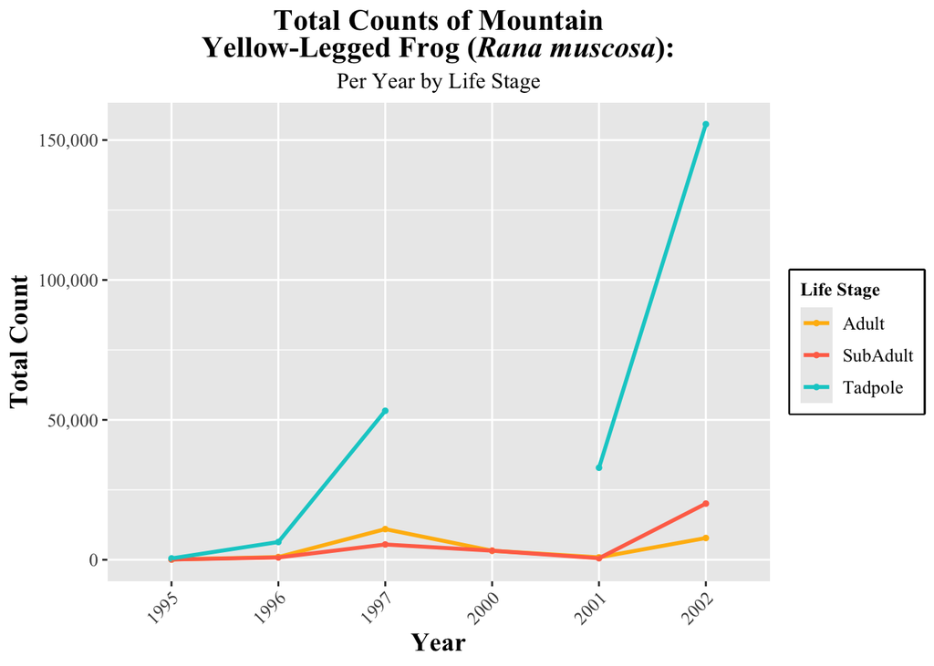

```r
#create a graph to visualize the number of mountain yellow-legged frogs of each life stage found for each year from 1995 to 2002
plot_one <- ggplot(ramu_sum_one, aes(x = factor(year), y = total_count, group = life_stage)) +
  geom_point(aes(color = life_stage),
             size = 1,
             show.legend = TRUE) +
  geom_line(aes(color = life_stage),
            size = 1,
            show.legend = TRUE) +
  labs(subtitle = "Per Year by Life Stage",
       x = "Year",
       y = "Total Count") +
  scale_color_manual(name = "Life Stage",
                     values = c("Adult" = "darkgoldenrod1",
                                "SubAdult" = "coral1",
                                "Tadpole" = "cyan3")) +
  scale_y_continuous(labels = scales::comma) +
  theme(plot.subtitle = element_text(family = "Times New Roman",
                                     size = 12,
                                     hjust = 0.5),
        axis.title = element_text(family = "Times New Roman",
                                  face = "bold",
                                  size = 14),
        axis.text.x = element_text(family = "Times New Roman",
                                   size = 10,
                                   angle = 45,
                                   hjust = 1,
                                   vjust = 1),
        axis.text.y = element_text(family = "Times New Roman",
                                   size = 10),
        legend.title = element_text(family = "Times New Roman",
                                    face = "bold",
                                    size = 10),
        legend.text = element_text(family = "Times New Roman",
                                   size = 10),
        legend.box.background = element_rect(color = "black", size = 1))

#finish formatting the plot to stand alone
ramu_life_year <- plot_one +
  labs(title = expression("Total Counts of Mountain<br>Yellow-Legged Frog (<i>Rana muscosa</i>):")) +
  theme(plot.title = element_markdown(family = "Times New Roman",
                                      face = "bold",
                                      size = 16,
                                      hjust = 0.5))

#print the graph
ramu_life_year
```

# IV. Visualization Two

Then we just focused on the adult and subadult life stages and determined the five lakes which has the greatest number of individuals across all of the years.

## a) Clean Data

```r
#create a new dataframe with just the mountain yellow-legged frog (Rana muscosa)
ramu_two <- amphibians_clean %>%
  filter(species == "RAMU") %>% #only select the desired species (RAMU)
  filter(life_stage %in% c("Adult", "SubAdult")) %>% #only keep the adults and subadults
  select(lake_id, species, life_stage, state, number, year) #select only the necessary columns

#create a new dataframe with the summary of the total number of individuals (adults and subadults) in the five most populated lakes
ramu_sum_two <- ramu_two %>%
  group_by(lake_id) %>% #group by the lake id
  summarize(total_count = sum(number)) %>% #get the total counts for each lake
  slice_max(total_count, n = 5, with_ties = TRUE) %>% #only keep the 5 most populated lakes (allowing ties)
  mutate(lake_id = factor(lake_id), #format the lake_id as a factor
         lake_id = fct_reorder(lake_id, total_count, .desc = TRUE)) #order the data in descending order
```

## b) Abundance by Lake

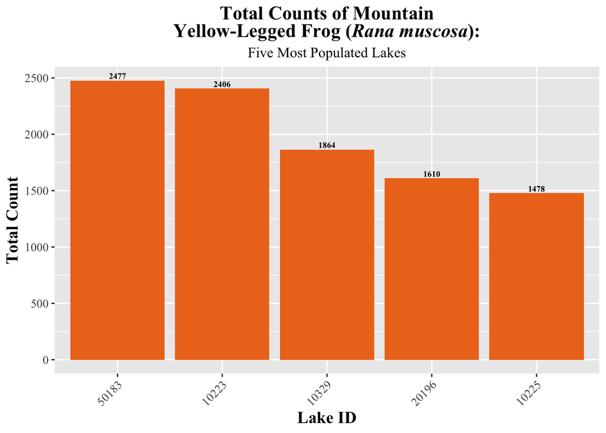

```r
#create a bar graph with total counts (over all years of the study) of adults and subadults in the 5 most populated takes
plot_two <- ggplot(ramu_sum_two, aes(x = factor(lake_id), y = total_count, fill = "chocolate2")) +
  geom_col(aes(x = factor(lake_id), y = total_count),
           show.legend = TRUE) +
  scale_fill_manual(values = c("chocolate2"),
                    labels = "Adults + SubAdults",
                    name = NULL) +
  geom_text(aes(label = total_count),
            vjust = -0.3,
            size = 2.5,
            family = "Times New Roman",
            fontface = "bold") +
  labs(subtitle = "Five Most Populated Lakes",
       x = "Lake ID",
       y = "Total Count") +
  theme(plot.subtitle = element_text(family = "Times New Roman",
                                     size = 12,
                                     hjust = 0.5),
        axis.title = element_text(family = "Times New Roman",
                                  face = "bold",
                                  size = 14),
        axis.text.x = element_text(family = "Times New Roman",
                                   size = 10,
                                   angle = 45,
                                   hjust = 1,
                                   vjust = 1),
        axis.text.y = element_text(family = "Times New Roman",
                                   size = 10),
        legend.title = element_text(family = "Times New Roman",
                                    face = "bold",
                                    size = 12),
        legend.text = element_text(family = "Times New Roman",
                                   size = 10))

#finish formatting the plot to stand alone
ramu_life_lake <- plot_two +
  labs(title = expression("Total Counts of Mountain<br>Yellow-Legged Frog (<i>Rana muscosa</i>):")) +
  theme(plot.title = element_markdown(family = "Times New Roman",
                                  face = "bold",
                                  size = 16,
                                  hjust = 0.5),
        legend.position = "none")

#print the graph
ramu_life_lake
```

# V. Combine Plots

Finally, we can combine the above plots into a single complex figure:

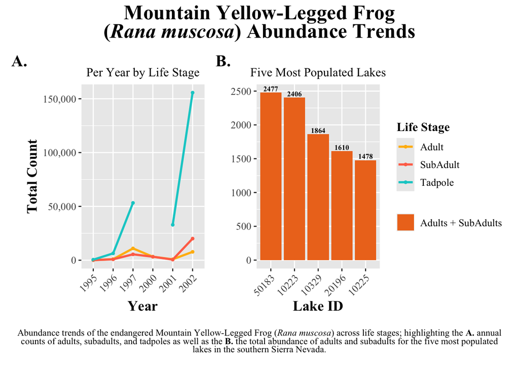

```r
#create a visualization from a combination of the two plots
combined <- plot_one + plot_two +
  plot_layout(ncol = 2,
              guides = "collect",
              axes = "collect") +
  plot_annotation(title = expression("Mountain Yellow-Legged Frog<br>(<i>Rana muscosa</i>) Abundance Trends"),
                  caption = expression("Abundance trends of the endangered Mountain Yellow-Legged Frog (<i>Rana muscosa</i>) across life stages; highlighting the <b>A.</b> annual<br> counts of adults, subadults, and tadpoles as well as the <b>B.</b> the total abundance of adults and subadults for the five most populated<br> lakes in the southern Sierra Nevada."),
                  tag_levels = "A",
                  tag_suffix = ".") &
  theme(plot.title = element_markdown(family = "Times New Roman",
                                      face = "bold",
                                      size = 20,
                                      hjust = 0.5),
        legend.position = "right",
        legend.title = element_text(family = "Times New Roman",
                                    face = "bold",
                                    size = 12),
        legend.text = element_text(family = "Times New Roman",
                                   size = 10),
        plot.tag = element_text(family = "Times New Roman",
                                face = "bold",
                                size = 16),
        plot.caption = element_markdown(family = "Times New Roman",
                                        size = 9,
                                        hjust = 0.5,
                                        margin = margin(t = 10, r = 20, b = 10, l = 20)))

#print the combined plot
combined
```

## References

Knapp, R. A., C. Pavelka, E. E. Hegeman, and T. C. Smith. 2020. “The Sierra Lakes Inventory Project: Non-Native Fish and Community Composition of Lakes and Ponds in the Sierra Nevada, California Ver 2.” https://doi.org/10.6073/pasta/d835832d7fd00d9e4466e44eea87fab3.